# Qing Hua Yu Data Processing and Visualizing Result

In this notebook, we processed the data that we collect from QingHuaYu website（https://allcp.net/）. We count how many poeple are online in 60-minute interval to gather what's the optimal time to pubish novel.

```python
import pandas as pd
import matplotlib.pyplot as plt
```

```python
QHYdf = pd.read_csv("./QingHuaYuResults.csv")
```

```python
Aug27th = QHYdf.loc[QHYdf['date']=="2023-09-15"]
```

Process date and time so that combined_datetime is a datetime object

```python
QHYdf['combined_datetime'] = QHYdf['date'] + ' ' +QHYdf['time']
QHYdf['combined_datetime']=pd.to_datetime(QHYdf['combined_datetime'])
```

Convert UTC to Beijing Standard Time. Seperate converted date from converted time.

It's important to make converted_time into int, otherwise the plot won't come out correctly.

```python
QHYdf['converted_date'] = QHYdf['combined_datetime'].dt.tz_localize('UTC').dt.tz_convert('Asia/Shanghai').dt.strftime('%Y-%m-%d')
QHYdf['converted_time'] = QHYdf['combined_datetime'].dt.tz_localize('UTC').dt.tz_convert('Asia/Shanghai').dt.strftime('%H').astype(int)
```

# Don't touch the dataframe above

```python
grouped_df = QHYdf.groupby('date').size().reset_index(name='count')
```

Create a list, add table of each day in the list

```python
dataList = []
for i in range(0,len(grouped_df)):
    obj = QHYdf.loc[QHYdf['date']== grouped_df.loc[i,"date"]].sort_values('converted_time').reset_index()
    dataList.append(obj)
```

Plot values

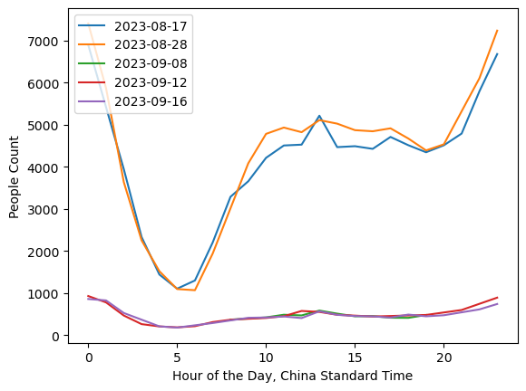

```python
for table in dataList:
    l = table.loc[0,"converted_date"]
    plt.plot(table["converted_time"],table["count"], label=l)
plt.legend(loc="upper left")
plt.xlabel('Hour of the Day, China Standard Time')
plt.ylabel('People Count')
```

# Discussion

We collected data from 5 different days. Although my intention is to collect data through 2023-8-17 to 2023-9-17, it seems like data wasn't collected correctly on AWS, and I'm left with only 5 days' data to work with.

The general trend of the data is that visitors peaked at midnight, signifying that most people come to the website at midnight to read novels.

Furthermore, the difference between the number of visitors in August and in Sempeter reveal the demographics of the website visitors. August is the time of summer break for students in China. In September, school starts. Typically when school starts, students’ access to the internet are limited due to school policies such as prohibiting students from bringing phones. The drastic difference between visitors in these 2 months suggest that most of the visitors to Qing Hua Yu are students.